# Brownlows Bets

Maria Cabanillas

12/04/2020

# 1 Introduction

At the first day of class there are 35 students in Math Statistics class and professor Brownlow always proposes this bet to his students "I will wager $2 to your bet of $1 that at least two people in today’s class have the same birthday. He tells me he has made that bet 637 times so far. Where do you think his profits are? Discuss this in a markdown document

# 2 Methods

We’ll solve this problem by resampling. We’ll setup days of the year, pick a random sample of 35, and see if two or more have the same birthday.

```r
daysYEAR=1:365
bDAYS=sample(daysYEAR,35,replace=TRUE)
length(unique(bDAYS))
```

```
## [1] 34
```

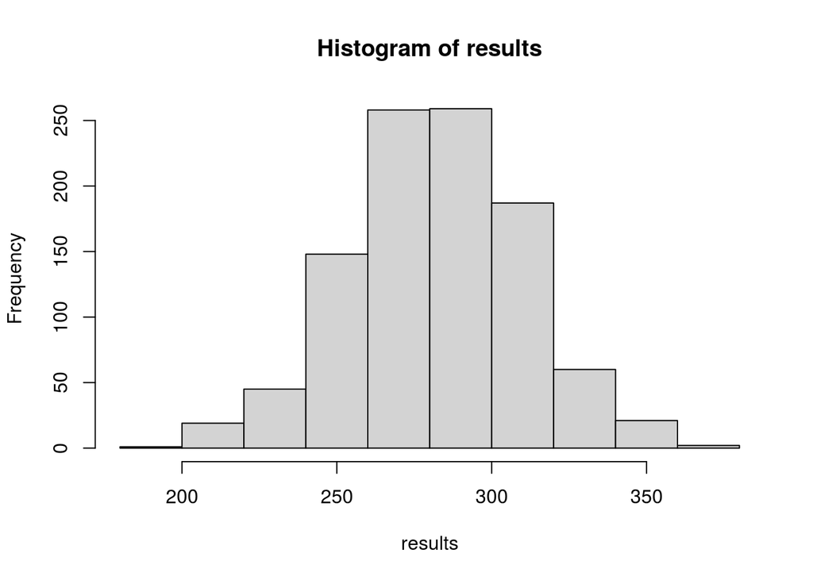

```r
results=vector("numeric")
for (j in 1:1000){
bank=0
for(i in 1:637){
  class=sample(daysYEAR,35,replace=TRUE)
  n=length(unique(class))
  if(n == 35)bank=bank-2
  else bank=bank+1
}
results[j]=bank
}
hist(results)
```

# 3 Profit Estimate

```r
favstats(results)
```

```
##  min  Q1 median  Q3 max    mean       sd    n missing
##  196 265    283 301 364 282.769 28.42234 1000       0
```

The expected anmount of money is 282.769

# 4 Confidence interval for Brownlow’s earnings

# 5 95% confidence interval

```r
results=vector("numeric")
for (j in 1:1000){
bank=0
for(i in 1:637){
  class=sample(daysYEAR,35,replace=TRUE)
  n=length(unique(class))
  if(n == 35)bank=bank-2
  else bank=bank+1
}
results[j]=bank
}
sortRESULTS=sort(results)
lcl=sortRESULTS[25]
ucl=sortRESULTS[975]
```

lower confidence limit= 226  
upper confidence limit= 334